# DQlab x efishery Data Challenge

by Soraya Rizka Keumala

23-06-2019

Report ini dibuat untuk mengikuti Data Challenge DQ Lab x efishery, Juni 2019.

Report ini mengandung Plotly. Untuk interactive visualization, dapat juga diliat di **Rpubs**: http://rpubs.com/sorayarizka/dqlabxefishery

## DATA PREPARATION

```r
a.konsum <- read.csv("data-perikanan-nasional/angkakonsumsiikan.csv")
a.benih <- read.csv("data-perikanan-nasional/jumlahproduksibenih.csv")
a.pembudi <- read.csv("data-perikanan-nasional/pembudidayaikannasional.csv")
a.olahan <- read.csv("data-perikanan-nasional/produkolahanikan.csv")
a.prodbudi <- read.csv("data-perikanan-nasional/produksibudidayanasional.csv")
a.perlakuan <- read.csv("data-perikanan-nasional/produksiperlakuanikannasional.csv")
```

Mengubah class `Tahun` dari integer ke factor

```r
a.konsum$Tahun <- as.factor(a.konsum$Tahun)
a.benih$Tahun <- as.factor(a.benih$Tahun)
a.pembudi$Tahun <- as.factor(a.pembudi$Tahun)
a.olahan$Tahun <- as.factor(a.olahan$Tahun)
a.prodbudi$Tahun <- as.factor(a.prodbudi$Tahun)
a.perlakuan$Tahun <- as.factor(a.perlakuan$Tahun)
```

**Daftar istilah**:

Volume: Volume produksi dihitung dalam bentuk berat basah ikan hasil tangkapan/budidaya Pembudidaya: Orang yang melakukan budidaya ikan

## REPORT

### Komoditas yang paling tinggi produksi budidayanya?

Data yang dipakai *produksibudidayanasional*, lalu diaggregate menurut variabel `NamaIkan` menggunakan *dplyr* sesuai dengan rata-rata produksi selama 2003-2012

```r
kom <- a.prodbudi %>%
  group_by(NamaIkan) %>%
  summarise(meanVol=round(mean(Volume),2))
kom <- na.omit(kom)
```

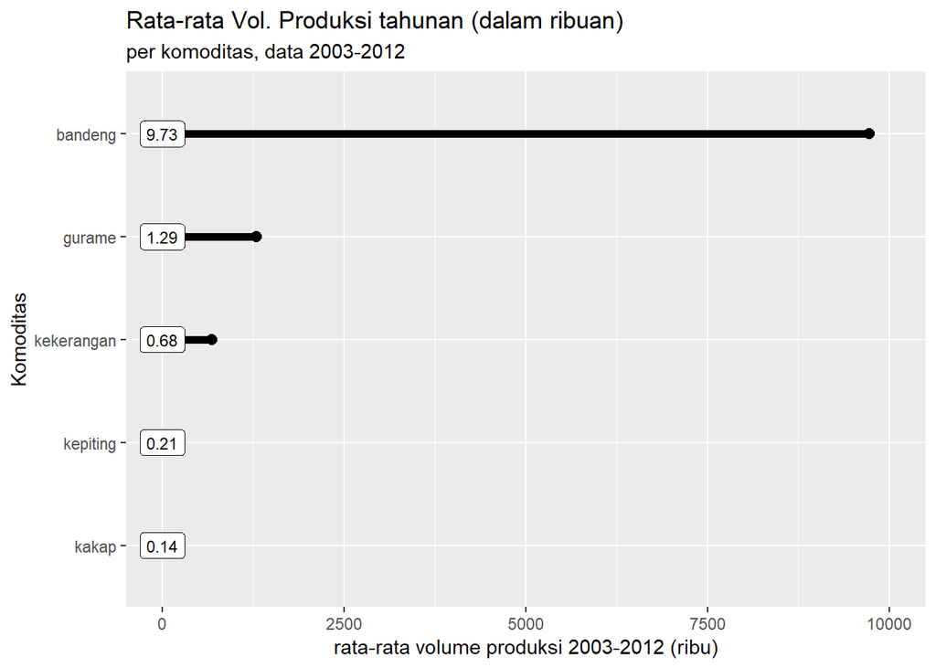

```r
ggplot(head(kom, 5), aes(x=0, xend=meanVol, y=reorder(NamaIkan, meanVol/1000), label=round(meanVol/1000, 2)))+
  geom_dumbbell(color="black", size=2)+
  geom_label(size=3)+
  xlim(0,10000)+
  labs(title="Rata-rata Vol. Produksi tahunan (dalam ribuan)", x="rata-rata volume produksi 2003-2012 (ribu)", subtitle="per komoditas, data 2003-2012", y="Komoditas", hjust=3)
```

### 5 Provinsi dengan nilai produksi budidaya tertinggi?

Masih memakai data *produksibudidayanasional*, kali ini diaggregate menurut `NamaProvinsi`, lalu diurutkan dari provinsi yang memiliki rata-rata volume produksi terbesar

```r
prodbudi_total <- a.prodbudi[a.prodbudi$NamaIkan =="total",]

prodbudi_total <- prodbudi_total %>%
  group_by(NamaProvinsi) %>%
  summarise(meanVolume=mean(Volume))

prodbudi_total2 <- prodbudi_total[order(-prodbudi_total$meanVolume),]
head(prodbudi_total2, 5)
```

| NamaProvinsi | meanVolume |
| --- | --- |
| Sulawesi Selatan | 869130.6 |
| Jawa Barat | 451832.8 |
| Sulawesi Tengah | 406675.9 |
| Jawa Timur | 387277.2 |
| Nusa Tenggara Timur | 367186.6 |

**Kesimpulan**: Sulawesi Selatan, Jawa Barat, Sulawesi Tengah, Jawa Timur, dan NTT adalah 5 provinsi dengan volume produksi budidaya tertinggi.

### Trend budidaya ikan nasional?

Trend budidaya dapat dikur dengan banyaknya benih, volume olahan, banyaknya pembudidaya, dan volume produks budidaya. Karena ingin melihat trend historis, saya membuat tabel aggregate menurut tahun.

```r
indo.benih <- a.benih %>%
  group_by(Tahun) %>%
  summarise(indoJumlah=sum(Jumlah)) %>%
  mutate(var="benih")
indo.benih <- indo.benih[-1,]

indo.olahan <- a.olahan[a.olahan$JenisOlahan =="semua",]
indo.olahan <- indo.olahan %>%
  group_by(Tahun) %>%
  summarise(indoJumlah=sum(Volume)) %>%
  mutate(var="olahan")
indo.olahan <- indo.olahan[-c(1,2),]

indo.pembudi <- a.pembudi %>%
  group_by(Tahun) %>%
  summarise(indoJumlah=sum(Jumlah)) %>%
  mutate(var="pembudidaya")
indo.pembudi <- indo.pembudi[-1,]

indo.prodbudi <- a.prodbudi[a.prodbudi$NamaIkan =="total",]
indo.prodbudi <- a.prodbudi %>%
  group_by(Tahun) %>%
  summarise(indoJumlah=sum(Volume)) %>%
  mutate(var="prodbudi")
```

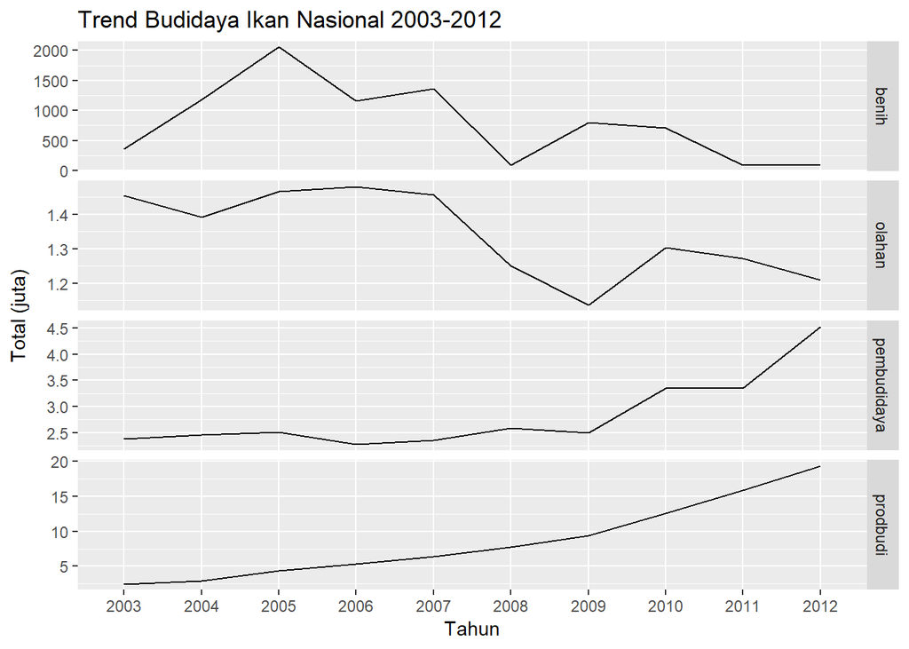

```r
com <- rbind(indo.benih, indo.olahan, indo.pembudi, indo.prodbudi)

trend.bud.nas <- ggplot(com, aes(Tahun, indoJumlah/1000000, group=var)) + #dalam juta
  geom_line()+
  facet_grid(var ~ .,scale="free_y")+
  labs(title="Trend Budidaya Ikan Nasional 2003-2012", y="Total (juta)")

trend.bud.nas
```

### Pertumbuhan Produksi menurut Pulau

Data yang diperoleh sebelumnya masih terbagi menurut provinsi. Dengan menggunakan function yang melihat ke angka pertama pada variabel `ProvinsiID`, saya membuat kolom baru yaitu `DaerahID` dan `Daerah` yang dibagi menurut pulau.

```r
reg <- a.prodbudi[a.prodbudi$NamaIkan =="total",]
reg$DaerahID <- substr(reg$ProvinsiID, 1, 1)
pulau <- function(x){
    if(x == 1){
      x <- "Sumatera"
    }else if(x == 3){
       x <- "Jawa"
     }else if(x ==2){
      x <- "Kepulauan Riau"
     }else if(x == 5){
       x <- "Bali-Nusa Tenggara"
     }else if(x == 6){
       x <- "Kalimantan"
     }else if(x == 7){
       x <- "Sulawesi"
     }else if(x == 8){
       x <- "Maluku"
    }else{
      x <- "Papua"}}

reg$Daerah <- as.factor(sapply(reg$DaerahID, pulau))
```

Membuat tabel aggregate berdasarkan variabel `Daerah` dan `Tahun`

```r
reg2 <- reg %>%
  group_by(Daerah, Tahun) %>%
  summarize(totalVol=sum(Volume))
```

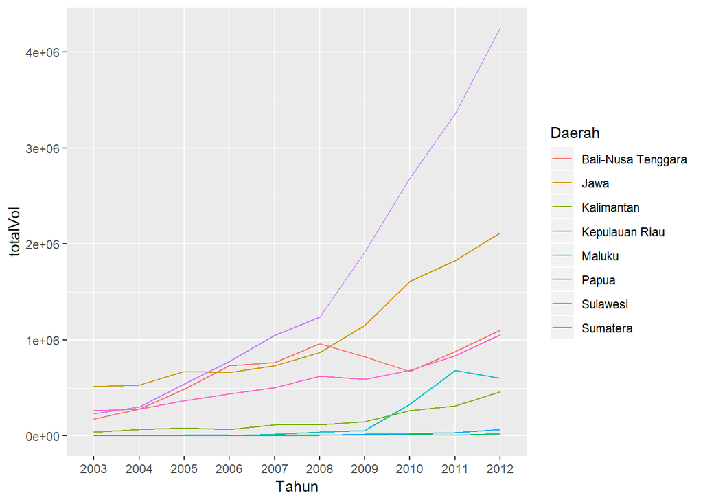

```r
reg2.plot <- ggplot(reg2, aes(x=Tahun, y=totalVol, col=Daerah, group=Daerah))+
  geom_line()
reg2.plot
```

**Kesimpulan**:

- Produksi budidaya Provinsi di pulau Sulawesi meningkat sangat tajam dalam 10 tahun.
- Budidaya ikan di Papua tidak terlalu populer
- Kepulauan Riau merupakan provinsi baru, jadi data masih sedikit.

## INSIGHT

### Model regresi terhadap jumlah produk olahan

Seberapa berpengaruh jumlah pembudidaya dan produksi budidaya terhadap jumlah produk olahan ikan? Untuk menjawabnya saya menggunakan metode **regresi linear**

Variabel independen: jumlah pembudidaya, volume produksi budidaya (per provinsi, per tahun)

Variabel dependen: jumlah produk olahan (per provinsi, per tahun)

```r
prov.olahan <- a.olahan %>%
  group_by(Tahun, NamaProvinsi) %>%
  summarise(provOlahan=sum(Volume))
prov.olahan <- prov.olahan[prov.olahan$Tahun != "2001" & prov.olahan$Tahun != "2002",]

prov.pembudi <- a.pembudi %>%
  group_by(Tahun, NamaProvinsi) %>%
  summarise(provPembudi=sum(Jumlah))
prov.pembudi <- prov.pembudi[prov.pembudi$Tahun != "2001" & prov.pembudi$Tahun != "2002",]

prov.prodbudi <- a.prodbudi %>%
  group_by(Tahun, NamaProvinsi) %>%
  summarise(provProd=sum(Volume))
prov.prodbudi <- prov.prodbudi[prov.olahan$Tahun != "2001" & prov.prodbudi$Tahun != "2002",]
```

```r
t1 <- as.data.frame(prov.olahan$Tahun)
t2 <- as.data.frame(prov.olahan$provOlahan)
t3 <- as.data.frame(prov.pembudi$provPembudi)
t4 <- as.data.frame(prov.prodbudi$provProd)
regresi <- cbind(t1, t2, t3, t4)
colnames(regresi) <- c("Tahun", "Olahan", "Pembudidaya", "Produksi")
```

**Membuat Model regresi linear**

```r
library(lmtest)
model_reg <- lm(Olahan ~ Produksi + Pembudidaya, regresi)
model_reg$coefficients
```

```
##   (Intercept)      Produksi   Pembudidaya
##  7.523994e+04 -2.530773e-03  7.907356e-02
```

```r
summary(model_reg)
```

```
##
## Call:
## lm(formula = Olahan ~ Produksi + Pembudidaya, data = regresi)
##
## Residuals:
##    Min     1Q Median     3Q    Max
## -90660 -57973 -34382   7574 731156
##
## Coefficients:
##               Estimate Std. Error t value Pr(>|t|)
## (Intercept)  7.524e+04  7.362e+03  10.219   <2e-16 ***
## Produksi    -2.531e-03  1.410e-02  -0.179   0.8577
## Pembudidaya  7.907e-02  4.480e-02   1.765   0.0785 .
## ---
## Signif. codes:  0 '***' 0.001 '**' 0.01 '*' 0.05 '.' 0.1 ' ' 1
##
## Residual standard error: 111800 on 327 degrees of freedom
## Multiple R-squared:  0.01063,    Adjusted R-squared:  0.004575
## F-statistic: 1.756 on 2 and 327 DF,  p-value: 0.1743
```

**Kesimpulan**: P-value yang didapatkan adalah lebih besar dari <0.05 dan Adjusted R square 0.4%, artinya **tidak ada korelasi** antara jumlah pembudidaya dan produksi terhadap jumlah produk olahan.

### Rasio Garis Pantai dan Volume Produksi (khusus perairan laut)

Apakah dengan luasnya garis pantai, produksi budidaya ikan laut juga semakin bertambah?

Kali ini saya menggunakan data lainnya (data garis pantai per provinsi) yang diambil dari Buku Statistik Sumber daya Laut dan Pesisir 2016, *Badan Pusat Statistik* (https://www.bps.go.id/publication/2016/12/20/9b1d875a713acca4d7c6d19c/statistik-sumber-daya-laut-dan-pesisir-2016.html)

```r
rasio <- a.perlakuan[a.perlakuan$JenisPerairan == "Laut",]
rasio <- rasio[rasio$JenisPerlakuan == "semua",]
rasio <- rasio %>%
        group_by(ProvinsiID) %>%
        summarise(meanVol=mean(Volume))
```

```r
garis.pt <- read.csv("data-perikanan-nasional/garis pantai.csv")
rasio2 <- cbind(rasio, garis.pt)

rasio2$rasioVolGP <- as.numeric(rasio2$meanVol)/rasio2$GarisPantai
rasio2 <- rasio2[,-3]
rasio2$DaerahID <- substr(rasio2$ProvinsiID, 1, 1)
rasio2$Daerah <- as.factor(sapply(rasio2$DaerahID, pulau))
```

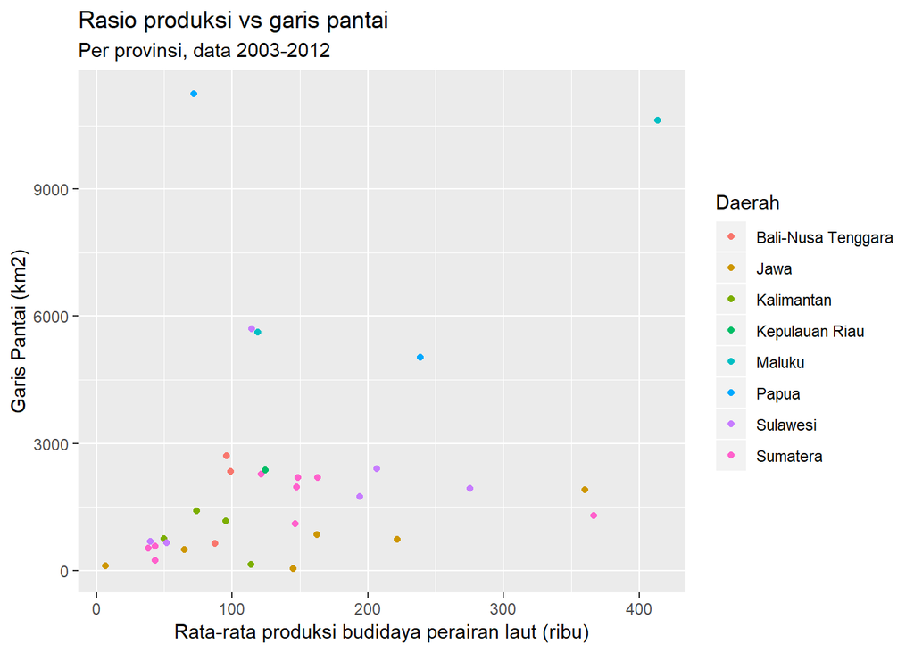

```r
a <- ggplot(rasio2, aes(x=meanVol/1000, y=GarisPantai, col=Daerah, name=NamaProvinsi))+
  geom_jitter()+
  labs(title="Rasio produksi vs garis pantai", x="Rata-rata produksi budidaya perairan laut (ribu)", y="Garis Pantai (km2)", subtitle="Per provinsi, data 2003-2012", hjust=3)

a
```

**Kesimpulan**L Ada provinsi yang memiliki garis pantai luas, namun produksi budidaya lautnya sedikit (Papua Barat), Namun ada juga banyak produksinya (cth: Maluku). Sumatra Utara & Jawa Timur merupakan provinsi yang garis pantainya kecil, namun produksi budidaya lautnya banyak.

Bila dibandingkan dengan grafik 5 Provinsi dengan jumlah produksi terbanyak di subbab sebelumnya, dimana Sulawesi Selatan dan Jawa Barat adalah provinsi yang paling banyak jumlah produksi budidaya (laut & umum), jumlah budidaya laut kedua provinsi tersebut tidak terlalu banyak (dalam grafik ini berada di kuadran bawah-tengah).

### Kesenjangan produksi budidaya antar daerah

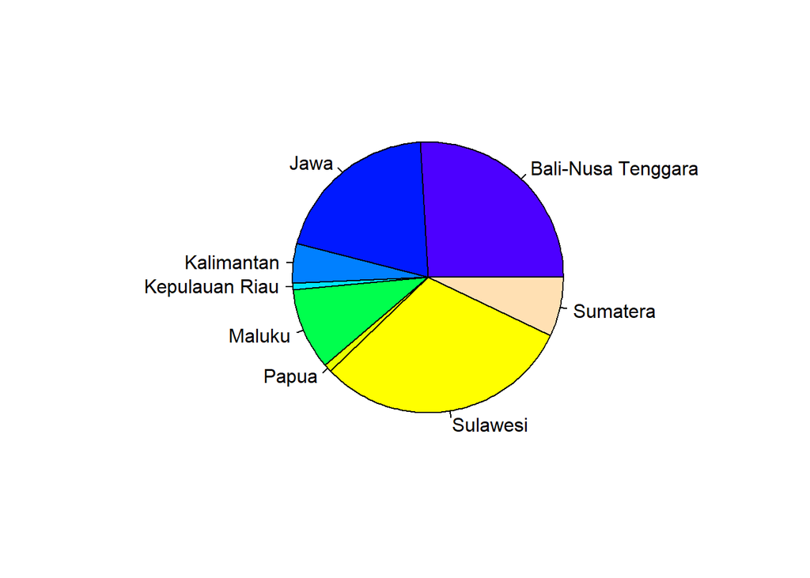

```r
reg1 <- reg %>%
  group_by(Daerah) %>%
  summarize(meanVol=mean(Volume))

reg1$percMeanVol <- reg1$meanVol/sum(reg1$meanVol)
pie(reg1$meanVol, labels=names(table(reg1$Daerah)), col=topo.colors(8))
```

## SUMBER

- Daftara Istilah Perikanan, *Badan Pusat Statistik* https://www.bps.go.id/subject/56/perikanan.html#subjekViewTab1
- Statistik Sumber daya Laut dan Pesisir 2016, *Badan Pusat Statistik* (https://www.bps.go.id/publication/2016/12/20/9b1d875a713acca4d7c6d19c/statistik-sumber-daya-laut-dan-pesisir-2016.html)

## GITHUB LINK

Rmarkdown dapat didownload di https://github.com/soraya-rk/dqlabxefishery